# GaussED: A Python Package for Sequential Experimental Design

[figure not shown]

[figure not shown]

Matthew Fisher, Onur Teymur, Chris Oates

# What is this about?

# `GaussED` Design

## `GaussED` Design Goals

## Package Structure

```
%%{init: {
  "flowchart": { "useMaxWidth": true, "nodeSpacing": 20, "rankSpacing": 160 },
  "themeVariables": { "fontSize": "24px", "fontFamily": "Iosevka, Times, serif" }
}}%%
graph TB

  %% --- GP construction ---
  subgraph GP_Definition["GP Definition"]
    Domain[Domain] --> GP
    Codomain[Codomain] --> GP
    Mean[MeanFun] --> GP
    Kernel[Kernel] --> GP
  end

  %% --- Operators / Probes ---
  subgraph GP_Operators["GP Operators"]
    Eval[Eval] --> Functional
    Functional[Functional] --> Probe
    Operator[Operator] --> Probe
    Partial[Partial] --> Operator
    Grad[Grad] --> Operator
    Linearise[Linearise] --> Operator
    Affine[Affine] --> Operator
    WeightedEval[WeightedEval] --> Functional
    Integral[Integral] --> Functional
    Probe --> ProbeStack
  end

  %% --- Model & posterior ---
  subgraph Model
    Likelihood --> GPModel
    GP --> GPModel
    ProbeStack --> GPModel
    GPModel -->|condition| PosteriorGP
  end


  %% --- Backend internals ---
  subgraph BackendGrp["Backend"]
    BackendNode[Backend] --> GPModel
    LinearSolver[Linear Solver] --> BackendNode
    BackendNode --> Reps["Exact / Inducing / Basis"]
    SpectralBasis[Spectral Basis] --> Reps
    Reps --> LinearSolver
  end

  ProbeStack -->|queries| PosteriorGP
  LinearSolver --> PosteriorGP
```

```
%%{init: {
  "flowchart": { "useMaxWidth": true, "nodeSpacing": 20, "rankSpacing": 160 },
  "themeVariables": { "fontSize": "24px", "fontFamily": "Iosevka, Times, serif" }
}}%%
graph TB

  %% --- GP construction ---
  subgraph GP_Definition["GP Definition"]
    Domain[Domain] --> GP
    Codomain[Codomain] --> GP
    Mean[MeanFun] --> GP
    Kernel[Kernel] --> GP
  end

  %% --- Operators / Probes ---
  subgraph GP_Operators["GP Operators"]
    Eval[Eval] --> Functional
    Functional[Functional] --> Probe
    Operator[Operator] --> Probe
    Partial[Partial] --> Operator
    Grad[Grad] --> Operator
    Linearise[Linearise] --> Operator
    Affine[Affine] --> Operator
    WeightedEval[WeightedEval] --> Functional
    Integral[Integral] --> Functional
    Probe --> ProbeStack
  end

  %% --- Model & posterior ---
  subgraph Model
    Likelihood --> GPModel
    GP --> GPModel
    ProbeStack --> GPModel
    GPModel -->|condition| PosteriorGP
  end


  %% --- Backend internals ---
  subgraph BackendGrp["Backend"]
    BackendNode[Backend] --> GPModel
    LinearSolver[Linear Solver] --> BackendNode
    BackendNode --> Reps["Exact / Inducing / Basis"]
    SpectralBasis[Spectral Basis] --> Reps
    Reps --> LinearSolver
  end

  ProbeStack -->|queries| PosteriorGP
  LinearSolver --> PosteriorGP
```

## Kernel Representations

There are multiple ways to represent a kernel:

1. **Exactly:**
2. **Inducing Points:**
3. **Basis/Operator Centric:**

## Spectral GP Approach

## Linear Solvers

# GP Operators (`gaussed/gp/gp_ops`)

## Math

$$f\sim\mathcal{GP}(m, k).$$

Want to compute or **condition upon** functionals of $f$:

$$f \mid \delta(f) = \delta(\mathrm{f}) \sim \mathcal{GP}(m, k).$$

This is achieved via linear operators

## `GaussED` Operator Syntax

The `gp_ops` module implements:

1. Allows custom hooks for analytic linear pushforwards (e.g. kernel integral, kernel gradient, etc.)
2. `Operator` outputs functions. `Functional` outputs real-values.
3. We use the `Probe` interface to compose operators and conduct measurements.

### Example

```python
partial_op = Partial(0) # an Operator
eval_fnl = Eval(X) # a functional

partial_probe = Probe((partial_op,), eval_fnl) # Composes
```

This probe returns the functional:
$$\frac{\partial}{\partial x_1} f(x_1,\ldots, x_d) \Big\lvert_{x = X}$$

To apply a probe:

$$f\sim \mathcal{GP}(m, k).$$

## The `Probe` protocol

## `Eval` Functional

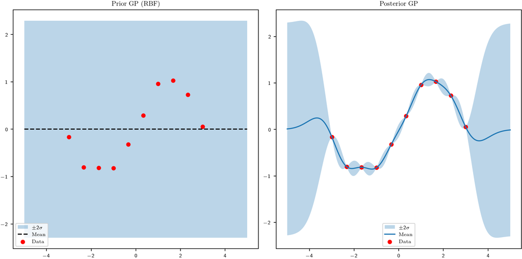

```python
# --- GP prior ---
domain   = Euclidean((1,))
codomain = Codomain((1,))
mean     = ZeroMeanFun(domain, codomain)
rbf_params = RBFParams(lengthscale=jnp.array(0.), amplitude=jnp.array(1.0))
kernel   = RBFKernel(rbf_params)
backend = ExactBackend(solverfns=solver_fns)

gp = GP(domain, codomain, mean, kernel, backend)

# --- Data ---
key = jax.random.PRNGKey(0)
Xtr = jnp.linspace(-3.0, 3.0, 10).reshape(-1, 1)
y_clean = jnp.sin(Xtr).squeeze()
noise = 0.1
y = y_clean + noise * jax.random.normal(key, shape=y_clean.shape)

# --- Probes ---
Ftr = Probe(ops=(), fnl=Eval(Xtr))
Xt = jnp.linspace(-5.0, 5.0, 300).reshape(-1, 1)
Fte = Probe(ops=(), fnl=Eval(Xt))

# --- Model / condition ---
lik = GaussianLikelihood()
model = GPModel(gp=gp, likelihood=lik)
post = model.condition(Ftr, y)

# --- Prior mean/var (for reference) ---
prior_mean = gp.mean_spec().eval(Xt)[:, 0]
prior_var  = jnp.diag(pack_ev2mat(gp.kernel_spec().k0(Xt, Xt), (1,), (1,)))

# --- Posterior mean/var ---
m_post = post.mean(Fte)
v_post = post.variance(Fte)

# --- Plot ---
xplot = Xt.squeeze()

plt.figure(figsize=(10,5))

# Prior
plt.subplot(1,2,1)
plt.title("Prior GP (RBF)")
plt.fill_between(xplot,
                 prior_mean - 2*jnp.sqrt(prior_var),
                 prior_mean + 2*jnp.sqrt(prior_var),
                 alpha=0.3, label="$\\pm 2 \\sigma$")
plt.plot(xplot, prior_mean, "k--", label="Mean")
plt.scatter(Xtr.squeeze(), y, s=25, c="r", label="Data")
plt.legend()

# Posterior
plt.subplot(1,2,2)
plt.title("Posterior GP")
plt.fill_between(xplot,
                 m_post.reshape(-1,) - 2*jnp.sqrt(v_post),
                 m_post.reshape(-1,) + 2*jnp.sqrt(v_post),
                 alpha=0.3, label="$\\pm2\\sigma$")
plt.plot(xplot, m_post, label="Mean")
plt.scatter(Xtr.squeeze(), y, s=25, c="r", label="Data")
plt.legend()

# plt.tight_layout()
# mplcyberpunk.add_glow_effects()
plt.show()
```

## `Partial` Operator

### $f \mid \partial_x f \sim \mathcal{GP}$

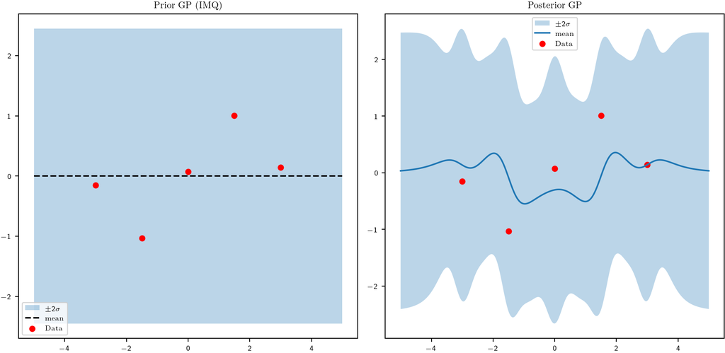

```python
# --- GP prior ---
domain   = Euclidean((1,))
codomain = Codomain((1,))
mean     = ZeroMeanFun(domain, codomain)
imq_params = IMQParams(lengthscale=jnp.array(0.5), amplitude=jnp.array(1.24751754), beta=jnp.array(1.0))
imq_kernel   = IMQKernel(imq_params)
backend = ExactBackend(solverfns=solver_fns)

gp = GP(domain, codomain, mean, imq_kernel, backend)

# --- Data ---
key = jax.random.PRNGKey(0)
Xtr = jnp.linspace(-3.0, 3.0, 5).reshape(-1, 1)
y_clean = jnp.sin(Xtr).squeeze()
noise = 0.04
y = y_clean + noise * jax.random.normal(key, shape=y_clean.shape)

# --- Probes ---
Ftr = Probe(ops=(Partial(0),), fnl=Eval(Xtr))
Xt = jnp.linspace(-5.0, 5.0, 300).reshape(-1, 1)
Fte = Probe(ops=(), fnl=Eval(Xt))

# --- Model / condition ---
lik = GaussianLikelihood(noise=DiagonalNoise(jnp.array([0.01])))
model = GPModel(gp=gp, likelihood=lik)
post = model.condition(Ftr, y)

# --- Prior mean/var (for reference) ---
prior_mean = gp.mean_spec().eval(Xt)[:, 0]
prior_var  = jnp.diag(pack_ev2mat(gp.kernel_spec().k0(Xt, Xt), (1,), (1,)))

# --- Posterior mean/var ---
m_post = post.mean(Fte)
v_post = post.variance(Fte)

# --- Plot ---
xplot = Xt.squeeze()

plt.figure(figsize=(10,5))

# Prior
plt.subplot(1,2,1)
plt.title("Prior GP (IMQ)")
plt.fill_between(xplot,
                 prior_mean - 2*jnp.sqrt(prior_var),
                 prior_mean + 2*jnp.sqrt(prior_var),
                 alpha=0.3, label="$\\pm2\\sigma$")
plt.plot(xplot, prior_mean, "k--", label="mean")
plt.scatter(Xtr.squeeze(), y, s=25, c="r", label="Data")
plt.legend()

# Posterior
plt.subplot(1,2,2)
plt.title("Posterior GP")
plt.fill_between(xplot,
                 m_post.reshape(-1,) - 2*jnp.sqrt(v_post),
                 m_post.reshape(-1,) + 2*jnp.sqrt(v_post),
                 alpha=0.3, label="$\\pm2\\sigma$")
plt.plot(xplot, m_post, label="mean")
plt.scatter(Xtr.squeeze(), y, s=25, c="r", label="Data")
plt.legend()

plt.tight_layout()
# mplcyberpunk.add_glow_effects()

plt.show()
```

## `Gradient` Operator

### $\nabla f \mid \mathcal{D}$

```python
# ----------------------------
# GP prior (2D, with ARD)
# ----------------------------
domain   = Euclidean((2,))
codomain = Codomain((1,))
mean     = ZeroMeanFun(domain, codomain)

solver_fns = SolverFns(chol_solve_hook(), chol_sqrt_hook(), chol_logdet_hook())

backend = ExactBackend(solverfns=solver_fns)

# ARD lengthscales (ℓ_x, ℓ_y); amplitude = σ²
imq_params = IMQParams(
    lengthscale=jnp.array([1.0, 0.7]),  # ARD
    amplitude=jnp.array(1.0),
    beta=jnp.array(1.0),
)
kernel  = IMQKernel(imq_params)

gp      = GP(domain, codomain, mean, kernel, backend)

# ----------------------------
# Synthetic 2D data
# ----------------------------
key = jax.random.PRNGKey(0)
n_tr = 60
Xtr = jax.random.uniform(key, (n_tr, 2), minval=-3.0, maxval=3.0)

def f_true(xy: jnp.ndarray) -> jnp.ndarray:
    # smooth, non-separable target
    x, y = xy[..., 0], xy[..., 1]
    return jnp.sin(x) * jnp.cos(0.8 * y) + 0.2 * x

y_clean = jax.vmap(f_true)(Xtr)
noise   = 0.1
y       = y_clean + noise * jax.random.normal(key, shape=y_clean.shape)

# ----------------------------
# Probes
# ----------------------------
Ftr   = Probe(ops=(), fnl=Eval(Xtr))                 # function values at Xtr
lik   = GaussianLikelihood(noise=DiagonalNoise(jnp.array([0.01])))
model = GPModel(gp=gp, likelihood=lik)
post  = model.condition(Ftr, y)

# Test grid for visualisation
nx = ny = 60
x1 = jnp.linspace(-3.5, 3.5, nx)
x2 = jnp.linspace(-3.5, 3.5, ny)
Xg1, Xg2 = jnp.meshgrid(x1, x2, indexing="xy")
Xgrid = jnp.stack([Xg1.ravel(), Xg2.ravel()], axis=1)     # (nx*ny, 2)

F_eval  = Probe(ops=(), fnl=Eval(Xgrid))                  # function probe
F_grad  = Probe(ops=(Grad(), ), fnl=Eval(Xgrid))  # gradient probe (∂/∂x, ∂/∂y)

# Posterior mean and gradient mean
m_post_grid = post.mean(F_eval).reshape(nx*ny)            # (N,)
g_post_grid = post.mean(F_grad).reshape(nx*ny, 2)         # (N, 2)
```

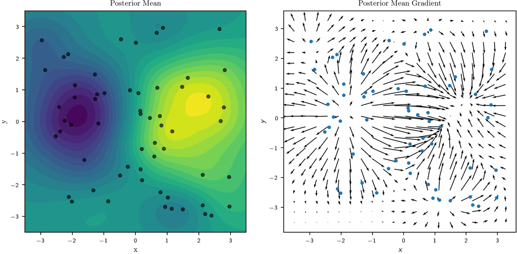

### $f \mid \nabla f$

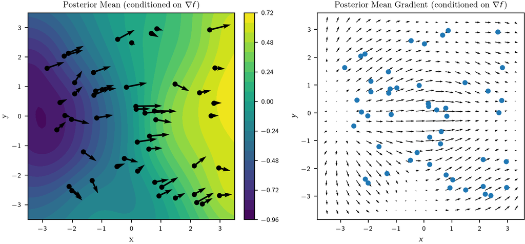

```python
# ----------------------------
# GP prior (2D, with ARD)
# ----------------------------
domain   = Euclidean((2,))
codomain = Codomain((1,))
mean     = ZeroMeanFun(domain, codomain)

solver_fns = SolverFns(svd_solve_hook(), svd_sqrt_hook(), svd_logdet_hook())
backend = ExactBackend(solverfns=solver_fns)

# ARD lengthscales (ℓ_x, ℓ_y); amplitude = σ²
imq_params = IMQParams(
    lengthscale=jnp.array([2., 1.9]),  # ARD
    amplitude=jnp.array(1.0),
    beta=jnp.array(0.01),
)
kernel  = IMQKernel(imq_params)
gp      = GP(domain, codomain, mean, kernel, backend)

# ----------------------------
# Synthetic 2D data
# ----------------------------
key = jax.random.PRNGKey(0)
n_tr = 50
Xtr = jax.random.uniform(key, (n_tr, 2), minval=-3.0, maxval=3.0)

def f_true(xy: jnp.ndarray) -> jnp.ndarray:
    x, y = xy[..., 0], xy[..., 1]
    return 0.2 * jnp.sin(x) * jnp.cos(0.8 * y) + 0.3 * x  # scalar

# --- gradient observations (condition on these!) ---
# g_true: (n_tr, 2) with columns [∂f/∂x, ∂f/∂y]
g_true = jax.vmap(jax.grad(f_true))(Xtr)

grad_noise = 0.1
key_g = jax.random.split(key, 2)[1]
g_obs = g_true + grad_noise * jax.random.normal(key_g, g_true.shape)  # (n_tr, 2)

# ----------------------------
# Probes (train on gradients)
# ----------------------------
# Gradient operator produces a 2-output (multioutput) GP at each location.
Ftr   = Probe(ops=(Grad(),), fnl=Eval(Xtr))        # gradient at Xtr, shape ~ (n_tr, 2)
# Per-output diagonal noise (broadcast across n_tr)
lik   = GaussianLikelihood(noise=DiagonalNoise(jnp.array([0.01, 0.01])))
model = GPModel(gp=gp, likelihood=lik)

# Condition on gradient observations
post  = model.condition(Ftr, g_obs)

# grid for visualisation
nx = ny = 60
x1 = jnp.linspace(-3.5, 3.5, nx)
x2 = jnp.linspace(-3.5, 3.5, ny)
Xg1, Xg2 = jnp.meshgrid(x1, x2, indexing="xy")
Xgrid = jnp.stack([Xg1.ravel(), Xg2.ravel()], axis=1)     # (nx*ny, 2)

F_eval = Probe(ops=(),        fnl=Eval(Xgrid))            # function values
F_grad = Probe(ops=(Grad(),), fnl=Eval(Xgrid))            # gradient values

# Posterior means
m_post_grid = post.mean(F_eval).reshape(nx*ny)            # (N,)
g_post_grid = post.mean(F_grad).reshape(nx*ny, 2)         # (N,2)

# Plotting
fig, axes = plt.subplots(1, 2, figsize=(10, 4), constrained_layout=False)

# 1) Posterior mean as filled contours
ax = axes[0]
M = np.array(m_post_grid).reshape(ny, nx)
cf = ax.contourf(np.array(Xg1), np.array(Xg2), M, levels=25)
ax.scatter(np.array(Xtr[:, 0]), np.array(Xtr[:, 1]), s=20, c="k", alpha=1.)

# overlay observed gradient arrows at training points
X = np.array(Xtr[:, 0])
Y = np.array(Xtr[:, 1])
U = np.array(g_obs[:, 0])   # ∂f/∂x
V = np.array(g_obs[:, 1])   # ∂f/∂y

ax.quiver(
    X, Y, U, V,
    angles="xy", scale_units="xy", scale=0.7,
    color="k",  zorder=3
)

ax.set_title("Posterior Mean (conditioned on $\\nabla f$)")
ax.set_xlabel("x"); ax.set_ylabel("y"); ax.set_aspect("equal", adjustable="box")
fig.colorbar(cf, ax=ax, fraction=0.046, pad=0.04)

# 2) Gradient quiver (posterior mean gradient)
ax = axes[1]
G = np.array(g_post_grid).reshape(ny, nx, 2)
step = max(1, nx // 20)  # thin arrows for clarity
ax.quiver(
    np.array(Xg1[::step, ::step]), np.array(Xg2[::step, ::step]),
    G[::step, ::step, 0], G[::step, ::step, 1],
    angles="xy", scale_units="xy", scale=1.1
)
ax.scatter(np.array(Xtr[:, 0]), np.array(Xtr[:, 1]), s=20, alpha=1.)
ax.set_title("Posterior Mean Gradient (conditioned on $\\nabla f$)")
ax.set_xlabel("$x$"); ax.set_ylabel("$y$"); ax.set_aspect("equal", adjustable="box")
# mplcyberpunk.add_glow_effects()

plt.show()
```

## Multioutput GPs

`GaussED` natively supports *tensor valued* kernels. A common choice is an **intrinsic coregionalisation model** (ICM) kernel.

### Coregional (ICM) Kernels

Suppose

$$(f_1,\ldots, f_D)^\top \sim \mathcal{GP}(m, K),$$

where $K$ is a matrix-valued kernel:
$$K:\mathcal{X}\times\mathcal{X} \rightarrow \mathbb{R}^{D\times D}.$$

Takes form:

$$K(x,y) = \Sigma \, k(x,y).$$

#### Option 1: Hard Code

```python
domain   = Euclidean((1,))
codomain = Codomain((2,))
mean     = ZeroMeanFun(domain, codomain)

# Kernel specification
imq_params = IMQParams(lengthscale=jnp.array(0.5), amplitude=jnp.array(1.2), beta=jnp.array(0.5))
imq_kernel = IMQKernel(imq_params)

coreg_par = CoregionParams(imq_params, L_params = jnp.array([[1.0, 0.8], [0.8, 1.0]]))
coreg_kernel = CoregionalKernel(imq_kernel, coreg_par)

backend = ExactBackend(solverfns=solver_fns)

# GP specification
gp = GP(domain, codomain, mean, coreg_kernel, backend)
gpmodel = GPModel(gp=gp, likelihood=lik)

ks = gp.kernel_spec()

x, y = jnp.array([[1.0]]), jnp.array([[2.0]])
Kxy = coreg_kernel(x, y, domain)

print("=== Coregionalised IMQ Kernel Evaluation ===")
print(f"Inputs: x = {x.ravel()[0]:.2f}, y = {y.ravel()[0]:.2f}")
print("Kernel Matrix (ICM):")
print(Kxy)
```

```
=== Coregionalised IMQ Kernel Evaluation ===
Inputs: x = 1.00, y = 2.00
Kernel Matrix (ICM):
[[[[1.25183594 0.76258125]
   [0.76258125 1.71637777]]]]
```

```python
mat = coreg_kernel._make_L()

print("=== Coregionalised Kernel Structure ===")
print("L (coregionalisation matrix):")
print(mat)
print("\nΣ = Lᵀ L (implied covariance across outputs)")
```

```
=== Coregionalised Kernel Structure ===
L (coregionalisation matrix):
[[1.3132617 0.       ]
 [0.8       1.3132617]]

Σ = Lᵀ L (implied covariance across outputs)
```

#### Option 2: ICM via `Affine` Operator

Alternatively, view an ICM as a **linear mixing** of independent outputs. Starting with an independent multi-output GP:

$$f(x)=\begin{pmatrix}f_1(x)\\ \vdots \\ f_D(x)\end{pmatrix},
\qquad
\operatorname{cov}\!\big[f(x),f(y)\big] \;=\; \mathrm{diag}\!\big(k_1(x,y),\ldots,k_D(x,y)\big),$$

apply a linear map $L\in\mathbb{R}^{D\times D}$:
$$f_{\text{ICM}}(x) \;=\; L\,f(x).$$

Then

$$\operatorname{cov}\!\big[f_{\text{ICM}}(x),f_{\text{ICM}}(y)\big]
\;=\; L\;\mathrm{diag}\!\big(k_1(x,y),\ldots,k_D(x,y)\big)\;L^\top.$$

```python
domain   = Euclidean((1,))
codomain = Codomain((2,))
mean     = ZeroMeanFun(domain, codomain)

# Independent outputs: block-diagonal kernel diag(k, k)
stacked_kern = StackedKernel((imq_kernel, imq_kernel))

backend = ExactBackend(solverfns=solver_fns)
gp = GP(domain, codomain, mean, stacked_kern, backend)
gpmodel = GPModel(gp=gp, likelihood=lik)

ks = gp.kernel_spec()

# --- Probes: Affine ∘ Eval ---
aff_op = Affine(mat)                  # f ↦ L f + c   (here c=0 internally)
eval_x = Eval(x)
eval_y = Eval(y)

probe_x = Probe((aff_op,), eval_x)
probe_y = Probe((aff_op,), eval_y)

# Kernel via operator calculus
K_icm_affine = probe_x.kernel(probe_y, ks, None)  # shape (2, 2)

print("=== ICM via Affine Operator ===")
print(f"Inputs: x = {x.ravel()[0]:.2f}, y = {y.ravel()[0]:.2f}")
print("\nICM kernel from operator construction:")
print(K_icm_affine)
```

```
=== ICM via Affine Operator ===
Inputs: x = 1.00, y = 2.00

ICM kernel from operator construction:
[[[[1.25183594 0.76258125]
   [0.76258125 1.71637777]]]]
```

They produce the same output!

## `Linearise` Operator

Suppose we have $f: \mathcal{X} \rightarrow \mathbb{R}^D$ and a function $g:\mathbb{R}^D\rightarrow \mathbb{R}^D$, then $g(f)$ is no longer Gaussian if $g$ isn’t linear :(

Linearise $g(y) \approx g(y_0) + J_g(y_0)(y - y_0)$. About reference $f_0$:

$$g(f(x)) \approx g(f_0(x)) + J_g(f_0(x))(f(x) - f_0(x)).$$

This is used in Warped-Sequential Active Bayesian integration (WSABI).

**Motivation**: Want to normalise posteriors (some important prior information is that posterior density is non-negative!)

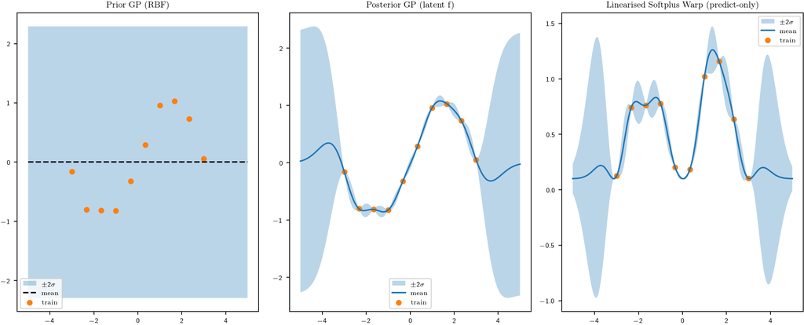

```python
# --- GP prior ---
domain   = Euclidean((1,))
codomain = Codomain((1,))
mean     = ZeroMeanFun(domain, codomain)
rbf_params = RBFParams(lengthscale=jnp.array(0.1), amplitude=jnp.array(1.0))
kernel   = RBFKernel(rbf_params)
backend  = ExactBackend(solverfns=solver_fns)

gp = GP(domain, codomain, mean, kernel, backend)

# --- Data ---
key = jax.random.PRNGKey(0)
Xtr = jnp.linspace(-3.0, 3.0, 10).reshape(-1, 1)
y_clean = jnp.sin(Xtr).squeeze()
noise = 0.1
y = y_clean + noise * jax.random.normal(key, shape=y_clean.shape)

# --- Probes ---
Ftr = Probe(ops=(), fnl=Eval(Xtr))
Xt  = jnp.linspace(-5.0, 5.0, 300).reshape(-1, 1)
Fte = Probe(ops=(), fnl=Eval(Xt))

# --- Model / condition ---
lik   = GaussianLikelihood()
model = GPModel(gp=gp, likelihood=lik)
post  = model.condition(Ftr, y)

# --- Prior mean/var (for reference) ---
prior_mean = gp.mean_spec().eval(Xt)[:, 0]
prior_var  = jnp.diag(pack_ev2mat(gp.kernel_spec().k0(Xt, Xt), (1,), (1,)))

# --- Posterior (unwarped) ---
m_post = post.mean(Fte)          # shape (n,1)
v_post = post.variance(Fte)      # shape (n,)

# ---------------------------------------------------------------------
# Linearised positivity warp at prediction time (Softplus)
# g(u) = softplus(u), J_g(u) computed automatically via AD
# Reference f0(x) := current posterior mean of the latent f
# ---------------------------------------------------------------------

def ref_fn(X: Array) -> Array:
    # posterior latent mean at inputs X (shape (n,1))
    return post.mean(Probe(ops=(), fnl=Eval(X)))  # (n,1)

softplus = lambda u: 0.1 + u ** 2 #jax.nn.softplus(u)  # (...,1) -> (...,1)

# jacobian=None => AD fallback via jax.jacfwd(softplus)
op_pos = Linearise(forward=softplus, jacobian=None, ref_fn=ref_fn)

# Test probe that applies the linearised warp
Fte_pos = Probe(ops=(op_pos,), fnl=Eval(Xt))

# Posterior under linearised warp (still Gaussian thanks to affine map)
m_pos = post.mean(Fte_pos)       # (n,1)
v_pos = post.variance(Fte_pos)   # (n,)

# --- Plot ---
xplot = Xt.squeeze()

plt.figure(figsize=(12,5))

# Prior
plt.subplot(1,3,1)
plt.title("Prior GP (RBF)")
plt.fill_between(xplot,
                 prior_mean - 2*jnp.sqrt(prior_var),
                 prior_mean + 2*jnp.sqrt(prior_var),
                 alpha=0.3, label="$\\pm 2\\sigma$")
plt.plot(xplot, prior_mean, "k--", label="mean")
plt.scatter(Xtr.squeeze(), y, s=25, label="train")
plt.legend()

# Posterior (unwarped)
plt.subplot(1,3,2)
plt.title("Posterior GP (latent f)")
plt.fill_between(xplot,
                 m_post.reshape(-1,) - 2*jnp.sqrt(v_post),
                 m_post.reshape(-1,) + 2*jnp.sqrt(v_post),
                 alpha=0.3, label="$\\pm 2\\sigma$")
plt.plot(xplot, m_post, label="mean")
plt.scatter(Xtr.squeeze(), y, s=25, label="train")
plt.legend()

# Posterior with linearised softplus warp
plt.subplot(1,3,3)
plt.title("Linearised Softplus Warp (predict-only)")
plt.fill_between(xplot,
                 m_pos.reshape(-1,) - 2*jnp.sqrt(v_pos),
                 m_pos.reshape(-1,) + 2*jnp.sqrt(v_pos),
                 alpha=0.3, label="$\\pm 2\\sigma$")
plt.plot(xplot, m_pos, label="mean")
plt.scatter(Xtr.squeeze(), softplus(y), s=25, label="train")
plt.legend()

plt.tight_layout()
plt.show()
```

## Bayesian Linear Solvers

A **Bayesian linear solver** interprets the problem of solving a linear system as a probabilistic inference task:

$$A x = y,
\quad A \in \mathbb{R}^{m \times D},
\quad x \in \mathbb{R}^D.$$

Given a set of candidate **search directions**
$$S \in \mathbb{R}^{n \times D},$$
we obtain *linear observations* of the form
$$W x = \underbrace{S^\top y}_{\text{observed}},
\quad W = S^\top A.$$

There are two natural approaches in `GaussED`:

1. `IndexDomain` GP: Define a Gaussian process over the discrete domain
   $$\mathcal{X} = \{0, \ldots, D-1\},$$
   so that
   $$\begin{pmatrix}
   f(0) \\ f(1) \\ \vdots \\ f(D-1)
   \end{pmatrix}
   =
   \begin{pmatrix}
   x_1 \\ x_2 \\ \vdots \\ x_D
   \end{pmatrix}.$$
   This is just a **multivariate normal prior** over the solution vector. The search direction observations are then linear functionals of this GP.
2. **Vector-valued GP:** Alternatively, treat $x$ directly as the mean of a **vector-valued GP**, with covariance modelling correlations between components.

Let’s generate a random problem:

```python
# Problem
N = 40
key = jax.random.PRNGKey(0)
key1, key2 = jax.random.split(key, 2)

A = jax.random.normal(key1, (N,N)) # matrix A

v_true = jax.random.normal(key2, (N,))
b = A @ v_true
```

If $A$ is SPD then CG search directions are optimal in terms of minimising the matrix norm to the solution.

If $A$ is not, then CG may not offer the best approach.

### Via `IndexDomain`

```python
index_domain = IndexDomain(N,  jnp.float64)

# Pick k directions: k standard basis columns
k = 20
idxs = jnp.linspace(0, N-1, k).round().astype(jnp.int32)
S = jnp.eye(N)[:, idxs]                               # (N,k)

# Build W and y
W = (S.T @ A)                                         # (k,N)  == S^T A
y = (S.T @ b).reshape(k, 1)                           # (k,1)

# GP prior on IndexDomain with delta kernel (Σ0 = α I)
index_domain = IndexDomain(N, jnp.float64)
codomain = Codomain((1,))
mean = ZeroMeanFun(index_domain, codomain)
delta_kernel = DeltaKernel(DeltaParams(amplitude=jnp.array(1.)))
backend = ExactBackend(solverfns=solver_fns)

gp = GP(index_domain, codomain, mean, delta_kernel, backend)
gpmodel = GPModel(gp=gp, likelihood=GaussianLikelihood())

# Observations via WeightedEval over all indices X_all
X_all = jnp.arange(N, dtype=jnp.int32).reshape(N, 1)
obs_fnl = WeightedEval(W=W, X=X_all)
probe_obs = Probe(ops=(), fnl=obs_fnl)
post = gpmodel.condition(probe_obs, y)                # posterior GP over v

# Evaluate posterior on all indices for plotting
probe_te = Probe(ops=(), fnl=Eval(X_all))
post_mean = post.mean(probe_te)
post_cov = post.covariance(probe_te)
```

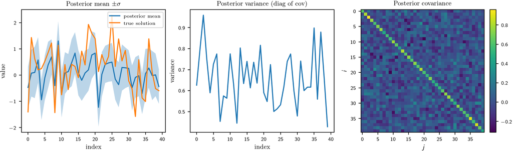

### Via a Vector-valued GP

# Sequential Experimental Design (`gaussed/sed`)

## Aims and Setup

**Aim:** Avoid tedious searching for good acquisition function for each new task.

**Set-up:**

- (truth) $\mathrm{f}: \mathcal{X} \rightarrow \mathbb{R}^D$.
- (prior) $\mathbb{P}$, e.g. a Gaussian process, supported on $\mathcal{F}$.
- (design set) $\mathcal{D} \subset \{\text{continuous linear functionals on } \mathcal{F}\}$.
- (data) $\boldsymbol{\delta}_{n-1}(\mathrm{f}) = [\delta_1(\mathrm{f}), \ldots, \delta_{n-1}(\mathrm{f})] \in \mathbb{R}^{D\times (n-1)}$

**Sequential Experimental Design:** At iteration $n$, select an experiment $\delta_n$ from the design set in order that an *acquisition function* is maximised
$$\delta_n \in \arg\max_{\delta \in \mathcal{D}} A(\delta; \mathbb{P}, \boldsymbol{\delta}_{n-1}(\mathrm{f})).$$

e.g. expected improvement for Bayesian optimisation.

but what if we don’t know a good acquisition function A?

## Quantities of Interest

Hard to come up with acquisition functions for general problems. However, it is very natural to have a **quantity of interest** (QoI)
$$Q(\mathrm{f}).$$

1. **Bayesian Optimisation (BO):** In Bayesian Optimisation, the quantity of interest is:
   $$Q(\mathrm{f}) = \quad \max_x \mathrm{f}(x).$$
   This is **non-linear**.
2. **Bayesian Cubature (BC):** In Bayesian Cubature, the quantity of interest is
   $$Q(\mathrm{f}) = \int_{R} \mathrm{f}(x) \,\mathrm{d}\mu$$
   This is **linear**.
3. **Regression:** In regression, the quantity of interest is the identity
   $$Q(\mathrm{f}) = \mathrm{f}$$

## A General-Purpose Acquisition Function

- **Idea:** Use classical but overlooked ideas from Bayesian decision theory!
- **Step 1:** An acquisition function from a utility function. The acquisition function is
  $$A(\delta; \mathbb{P} , \boldsymbol{\delta}_{n-1}(\mathsf{f})) = \int \underbrace{ U(\boldsymbol{\delta}_{n-1}(\mathsf{f}), \delta(\mathrm{f}) ) }_{\text{utility function}} \; \mathrm{d}\mathbb{P}(\mathrm{f} | \boldsymbol{\delta}_{n-1}(\mathsf{f}) )$$
  where $\mathbb{P}(\cdot | \boldsymbol{\delta}_n(\mathsf{f}) )$ denotes the conditional distribution given the observed data $\boldsymbol{\delta}_n(\mathsf{f})$.
- **Step 2: a utility function from a loss function** The utility function
  $$\begin{equation}
  U(\boldsymbol{\delta}_{n-1}(\mathsf{f}), \delta(\mathrm{f}) ) = - \min_{\mathrm{g} \in \mathcal{F}} \int \underbrace{ L(\mathrm{g},\mathrm{g}') }_{\text{loss function}} \; \mathrm{d}\mathbb{P}(\mathrm{g}' | \boldsymbol{\delta}_{n-1}(\mathsf{f}) , \delta(\mathrm{f}) ) , \label{eq: U bayes risk}
  \end{equation}$$
  i.e. the negative expected loss when the Bayes decision rule $\mathrm{g}$ is used.
- So just need to pick a task-specific loss function $L$.
- But (1) seems to involve optimisation?

# Applications

# Final Remarks

- **Proof-of-Concept:** An engine for automatic linear Gaussian conditioning, coupled to a high-level programming language for PN. ✓
- **But:** GaussED is not (yet) at a stage of development where you should use it! Solutions ‘On the Market’:
  - ▶ PPLs for conditioning GPs on function value data (e.g. Rasmussen and Nickisch, 2010; Matthews et al., 2017)
  - ▶ Rainforth (2017, Chapter 11) and Ouyang et al. (2016); Kandasamy et al. (2018), who provided a high-level PPL for Bayesian SED.
  - ▶ For numerics, the ProbNum Python library (ProbNum, 2021)!
  - ▶ Paleyes et al. (2019) developed a PPL called Emukit, in which computer model emulation, Bayesian optimisation, and a number of probabilistic numerical methods are automated.
- **Thank you for your attention!**

## References

- **Kandasamy, K., Neiswanger, W., Zhang, R., Krishnamurthy, A., Schneider, J., and Poczos, B.** (2018). Myopic Bayesian design of experiments via posterior sampling and probabilistic programming. *arXiv:1805.09964.*
- **Matthews, A. G. d. G., Van Der Wilk, M., Nickson, T., Fujii, K., Boukouvalas, A., León-Villagrá, P., Ghahramani, Z., and Hensman, J.** (2017). GPflow: A Gaussian process library using tensorflow. Journal of Machine Learning Research, 18(40):1–6.
- **Ouyang, L., Tessler, M. H., Ly, D., and Goodman, N.** (2016). Practical optimal experiment design with probabilistic programs. *arXiv:1608.05046.*
- **Paleyes, A., Pullin, M., Mahsereci, M., Lawrence, N., and González, J.** (2019). Emulation of physical processes with Emukit. In *Proceedings of the 2nd Workshop on Machine Learning and the Physical Sciences, NeurIPS*.
- **ProbNum** (2021). ProbNum: Learn to approximate. Approximate to learn. www.probabilistic-numerics.org.
- **Rainforth, T. W. G.** (2017). Automating inference, learning, and design using probabilistic programming. PhD thesis, University of Oxford.
- **Rasmussen, C. E. and Nickisch, H.** (2010). Gaussian processes for machine learning (GPML) toolbox. *The Journal of Machine Learning Research*, 11:3011–3015.
- **Solin, A. and Särkkä, S.** (2019). Hilbert space methods for reduced-rank Gaussian process regression. *Statistics and Computing*, 30(2):419–446